# FinalP2

Jonah Smith

2025-04-10

```r
library(tidyverse)
```

```r
library(coefplot)
library(rstanarm)
library(caret)
df <- readr::read_csv("paint_project_train_data.csv", col_names = TRUE)
glimpse(df)
```

```
## Rows: 835
## Columns: 8
## $ R          <dbl> 172, 26, 172, 28, 170, 175, 90, 194, 171, 122, 0, 88, 144, …
## $ G          <dbl> 58, 88, 94, 87, 66, 89, 78, 106, 68, 151, 121, 140, 82, 163…
## $ B          <dbl> 62, 151, 58, 152, 58, 65, 136, 53, 107, 59, 88, 58, 132, 50…
## $ Lightness  <chr> "dark", "dark", "dark", "dark", "dark", "dark", "dark", "da…
## $ Saturation <chr> "bright", "bright", "bright", "bright", "bright", "bright",…
## $ Hue        <dbl> 4, 31, 8, 32, 5, 6, 34, 10, 1, 21, 24, 22, 36, 16, 26, 12, …
## $ response   <dbl> 12, 10, 16, 10, 11, 16, 10, 19, 14, 25, 14, 19, 14, 38, 15,…
## $ outcome    <dbl> 1, 1, 1, 0, 0, 0, 0, 0, 0, 0, 0, 0, 0, 0, 0, 0, 0, 0, 1, 1,…
```

```r
##dfii will contain the logit transformed response, rather than response
dfii <- df %>%
  mutate(y = boot::logit( (response - 0) / (100 - 0) ) ) %>%
  select(R, G, B,
         Lightness, Saturation, Hue,
         y)

dfii %>% glimpse()
```

```
## Rows: 835
## Columns: 7
## $ R          <dbl> 172, 26, 172, 28, 170, 175, 90, 194, 171, 122, 0, 88, 144, …
## $ G          <dbl> 58, 88, 94, 87, 66, 89, 78, 106, 68, 151, 121, 140, 82, 163…
## $ B          <dbl> 62, 151, 58, 152, 58, 65, 136, 53, 107, 59, 88, 58, 132, 50…
## $ Lightness  <chr> "dark", "dark", "dark", "dark", "dark", "dark", "dark", "da…
## $ Saturation <chr> "bright", "bright", "bright", "bright", "bright", "bright",…
## $ Hue        <dbl> 4, 31, 8, 32, 5, 6, 34, 10, 1, 21, 24, 22, 36, 16, 26, 12, …
## $ y          <dbl> -1.9924302, -2.1972246, -1.6582281, -2.1972246, -2.0907411,…
```

Part ii: Regression - iiA) Linear models Before using more advanced methods, you need to develop a baseline understanding for the behavior of the LOGIT-transformed response as a function of the inputs using linear modeling techniques. Use lm() to fit linear models. You must use the following: • Intercept-only model – no INPUTS!

```r
##function to be used for feature analysis in the models
plot_top_t_coefs <- function(model, top_n = 10, title = "Top Predictors by |t-value|") {
  broom::tidy(model) %>%
    mutate(t_value = estimate / std.error) %>%
    arrange(desc(abs(t_value))) %>%
    slice(1:top_n) %>%
    ggplot(aes(x = reorder(term, abs(t_value)), y = estimate)) +
    geom_col(fill = "steelblue") +
    geom_errorbar(aes(ymin = estimate - std.error, ymax = estimate + std.error), width = 0.2) +
    coord_flip() +
    labs(title = title,
         x = "Predictor",
         y = "Coefficient Estimate") +
    theme_minimal()
}
```

```r
interceptonly = lm(y ~ 1, data = dfii)

interceptonly
```

```
##
## Call:
## lm(formula = y ~ 1, data = dfii)
##
## Coefficients:
## (Intercept)
##     -0.1094
```

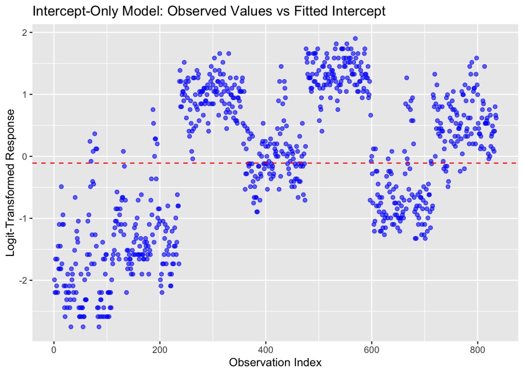

```r
# The fitted intercept
fitted_value <- coef(interceptonly)["(Intercept)"]

# Add an index column for plotting
dfii <- dfii %>% mutate(Index = 1:nrow(dfii))

# Plot observed y values and the constant fitted line
ggplot(dfii, aes(x = Index, y = y)) +
  geom_point(color = "blue", alpha = 0.6) +
  geom_hline(yintercept = fitted_value, linetype = "dashed", color = "red") +
  labs(title = "Intercept-Only Model: Observed Values vs Fitted Intercept",
       x = "Observation Index",
       y = "Logit-Transformed Response")
```

An intercept only model essentially just places the predicted logit-response value as the mean of the logit-response across all values

• Categorical variables only – linear additive

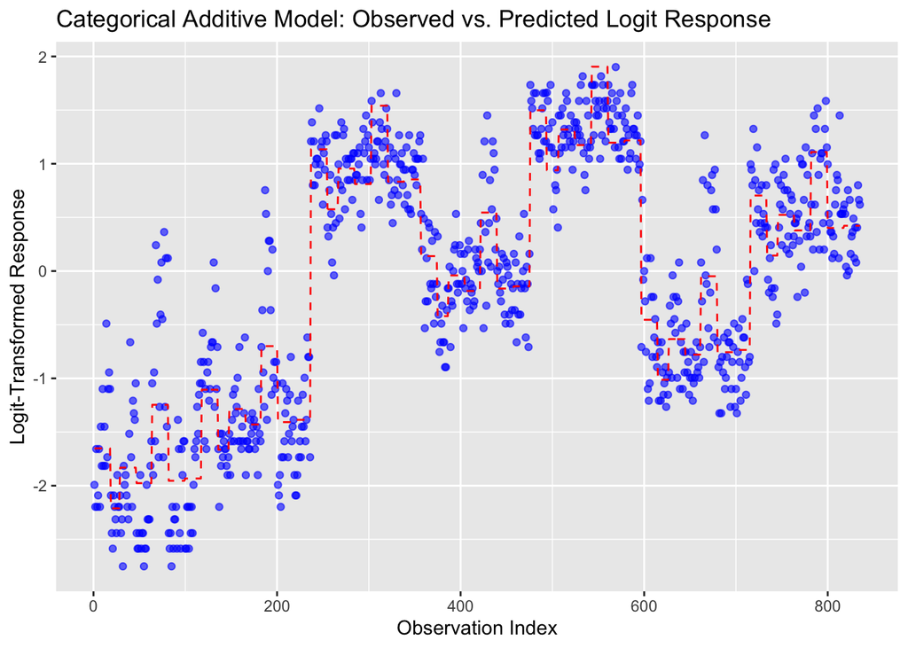

```r
cat_model <- lm(y ~ factor(Lightness) + factor(Saturation), data = dfii)

dfii <- dfii %>%
  mutate(Index = 1:n(),
         predicted = predict(cat_model))

ggplot(dfii, aes(x = Index)) +
  geom_point(aes(y = y), color = "blue", alpha = 0.6) +
  geom_line(aes(y = predicted), color = "red", linetype = "dashed") +
  labs(title = "Categorical Additive Model: Observed vs. Predicted Logit Response",
       x = "Observation Index",
       y = "Logit-Transformed Response")
```

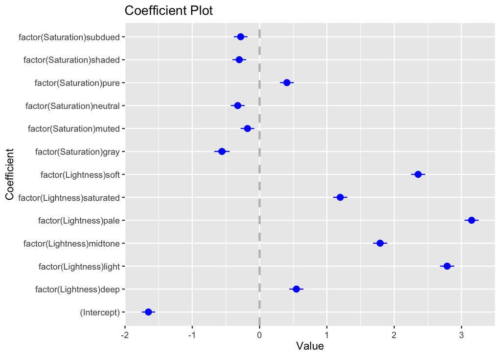

```r
coefplot(cat_model)
```

```r
summary(cat_model)
```

```
##
## Call:
## lm(formula = y ~ factor(Lightness) + factor(Saturation), data = dfii)
##
## Residuals:
##      Min       1Q   Median       3Q      Max
## -1.07738 -0.27019 -0.01581  0.22503  1.61005
##
## Coefficients:
##                            Estimate Std. Error t value Pr(>|t|)
## (Intercept)                -1.65197    0.05002 -33.023  < 2e-16 ***
## factor(Lightness)deep       0.54659    0.05276  10.360  < 2e-16 ***
## factor(Lightness)light      2.78682    0.05265  52.931  < 2e-16 ***
## factor(Lightness)midtone    1.79125    0.05276  33.952  < 2e-16 ***
## factor(Lightness)pale       3.15045    0.05255  59.954  < 2e-16 ***
## factor(Lightness)saturated  1.19798    0.05276  22.707  < 2e-16 ***
## factor(Lightness)soft       2.35564    0.05265  44.741  < 2e-16 ***
## factor(Saturation)gray     -0.55911    0.05729  -9.759  < 2e-16 ***
## factor(Saturation)muted    -0.17976    0.05105  -3.521 0.000453 ***
## factor(Saturation)neutral  -0.32465    0.05147  -6.308 4.62e-10 ***
## factor(Saturation)pure      0.40588    0.05105   7.951 6.12e-15 ***
## factor(Saturation)shaded   -0.30206    0.05105  -5.917 4.81e-09 ***
## factor(Saturation)subdued  -0.28097    0.05105  -5.504 4.97e-08 ***
## ---
## Signif. codes:  0 '***' 0.001 '**' 0.01 '*' 0.05 '.' 0.1 ' ' 1
##
## Residual standard error: 0.4052 on 822 degrees of freedom
## Multiple R-squared:  0.8846, Adjusted R-squared:  0.8829
## F-statistic: 525.3 on 12 and 822 DF,  p-value: < 2.2e-16
```

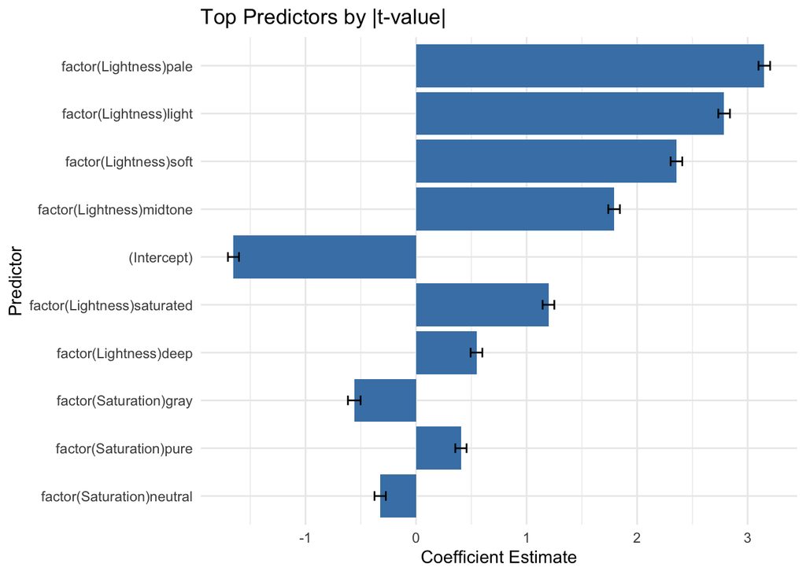

```r
plot_top_t_coefs(cat_model)
```

This model seems to capture some of the behavior of the data (unlike the intercept only).

• Continuous variables only – linear additive

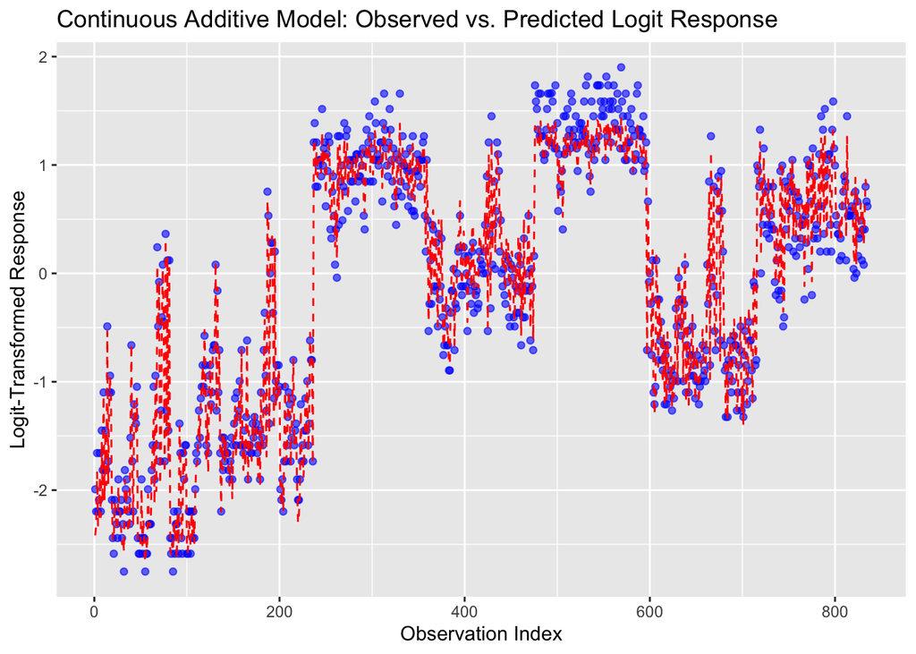

```r
cont_model <- lm(y ~ R + G + B + Hue, data = dfii)


dfii <- dfii %>%
  mutate(Index = 1:n(),
         predicted = predict(cont_model))

ggplot(dfii, aes(x = Index)) +
  geom_point(aes(y = y), color = "blue", alpha = 0.6) +
  geom_line(aes(y = predicted), color = "red", linetype = "dashed") +
  labs(title = "Continuous Additive Model: Observed vs. Predicted Logit Response",
       x = "Observation Index",
       y = "Logit-Transformed Response")
```

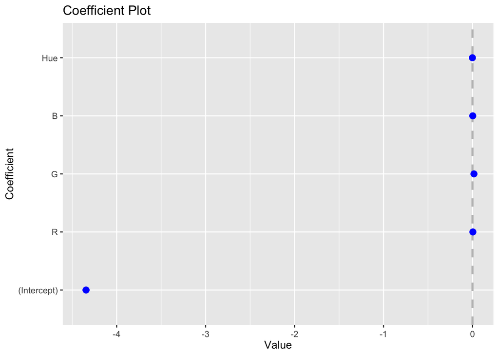

```r
coefplot(cont_model)
```

```r
summary(cont_model)
```

```
##
## Call:
## lm(formula = y ~ R + G + B + Hue, data = dfii)
##
## Residuals:
##      Min       1Q   Median       3Q      Max
## -0.22250 -0.09835 -0.01210  0.07044  0.46987
##
## Coefficients:
##               Estimate Std. Error  t value Pr(>|t|)
## (Intercept) -4.3445111  0.0205160 -211.762   <2e-16 ***
## R            0.0045105  0.0001504   29.984   <2e-16 ***
## G            0.0165633  0.0002098   78.964   <2e-16 ***
## B            0.0031265  0.0001473   21.221   <2e-16 ***
## Hue         -0.0007706  0.0005745   -1.341     0.18
## ---
## Signif. codes:  0 '***' 0.001 '**' 0.01 '*' 0.05 '.' 0.1 ' ' 1
##
## Residual standard error: 0.1295 on 830 degrees of freedom
## Multiple R-squared:  0.9881, Adjusted R-squared:  0.988
## F-statistic: 1.724e+04 on 4 and 830 DF,  p-value: < 2.2e-16
```

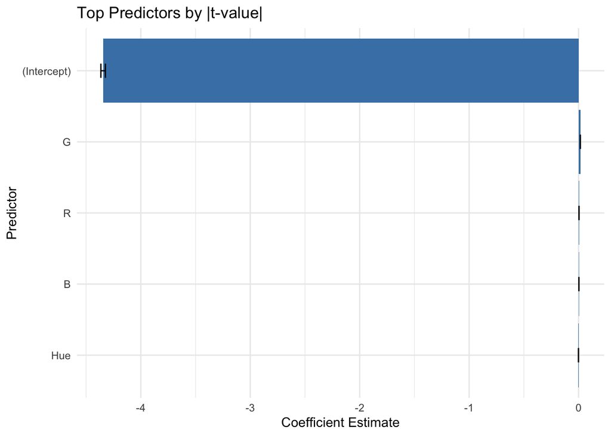

```r
plot_top_t_coefs(cont_model)
```

This model seems to have more granularity than the categorical linear additive model. Since index is on the x axis here (just as a general idea of observed vs predicted), we can’t say anythign about the quality of the fit or risk of overfitting.

• All categorical and continuous variables – linear additive

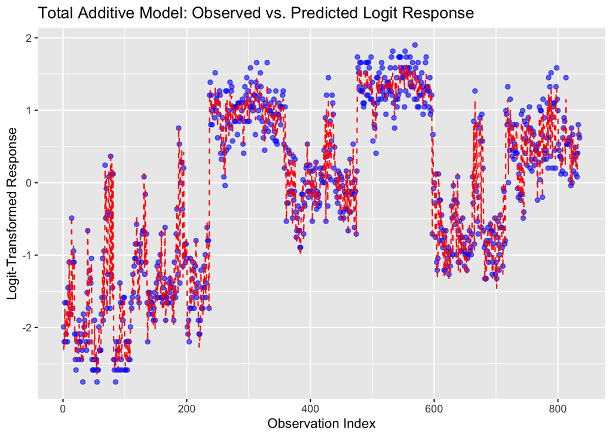

```r
tot_model <- lm(y ~ R + G + B + Hue + factor(Lightness) + factor(Saturation), data = dfii)

dfii <- dfii %>%
  mutate(Index = 1:n(),
         predicted = predict(tot_model))

ggplot(dfii, aes(x = Index)) +
  geom_point(aes(y = y), color = "blue", alpha = 0.6) +
  geom_line(aes(y = predicted), color = "red", linetype = "dashed") +
  labs(title = "Total Additive Model: Observed vs. Predicted Logit Response",
       x = "Observation Index",
       y = "Logit-Transformed Response")
```

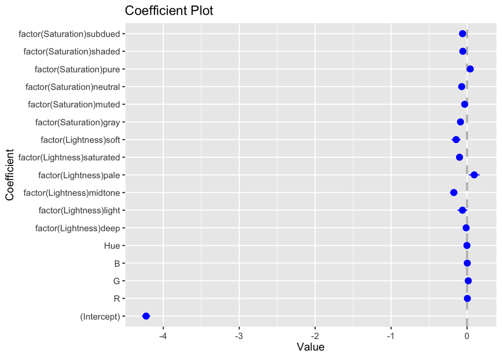

```r
coefplot(tot_model)
```

```r
summary(tot_model)
```

```
##
## Call:
## lm(formula = y ~ R + G + B + Hue + factor(Lightness) + factor(Saturation),
##     data = dfii)
##
## Residuals:
##      Min       1Q   Median       3Q      Max
## -0.25819 -0.05399 -0.00678  0.04491  0.34607
##
## Coefficients:
##                              Estimate Std. Error  t value Pr(>|t|)
## (Intercept)                -4.2258728  0.0273303 -154.622  < 2e-16 ***
## R                           0.0044892  0.0001107   40.537  < 2e-16 ***
## G                           0.0162911  0.0001672   97.413  < 2e-16 ***
## B                           0.0033393  0.0001647   20.273  < 2e-16 ***
## Hue                        -0.0013567  0.0004083   -3.323 0.000931 ***
## factor(Lightness)deep      -0.0118455  0.0130987   -0.904 0.366088
## factor(Lightness)light     -0.0601306  0.0335276   -1.793 0.073268 .
## factor(Lightness)midtone   -0.1738661  0.0244948   -7.098 2.75e-12 ***
## factor(Lightness)pale       0.0950712  0.0355656    2.673 0.007665 **
## factor(Lightness)saturated -0.0989027  0.0179408   -5.513 4.74e-08 ***
## factor(Lightness)soft      -0.1439578  0.0297722   -4.835 1.59e-06 ***
## factor(Saturation)gray     -0.0860694  0.0132098   -6.516 1.26e-10 ***
## factor(Saturation)muted    -0.0312756  0.0112263   -2.786 0.005461 **
## factor(Saturation)neutral  -0.0701534  0.0114444   -6.130 1.37e-09 ***
## factor(Saturation)pure      0.0426210  0.0117613    3.624 0.000308 ***
## factor(Saturation)shaded   -0.0554145  0.0113378   -4.888 1.23e-06 ***
## factor(Saturation)subdued  -0.0590453  0.0113080   -5.222 2.25e-07 ***
## ---
## Signif. codes:  0 '***' 0.001 '**' 0.01 '*' 0.05 '.' 0.1 ' ' 1
##
## Residual standard error: 0.08862 on 818 degrees of freedom
## Multiple R-squared:  0.9945, Adjusted R-squared:  0.9944
## F-statistic:  9258 on 16 and 818 DF,  p-value: < 2.2e-16
```

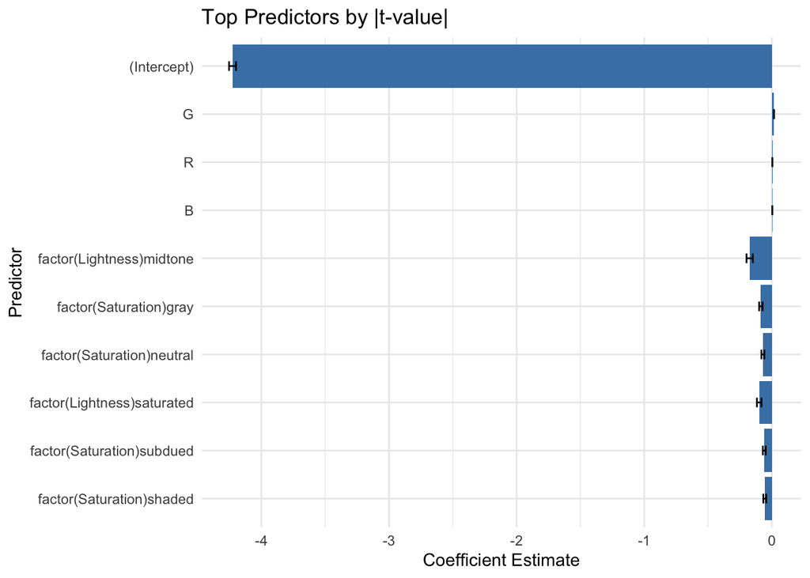

```r
plot_top_t_coefs(tot_model)
```

• Interaction of the categorical inputs with all continuous inputs main effects

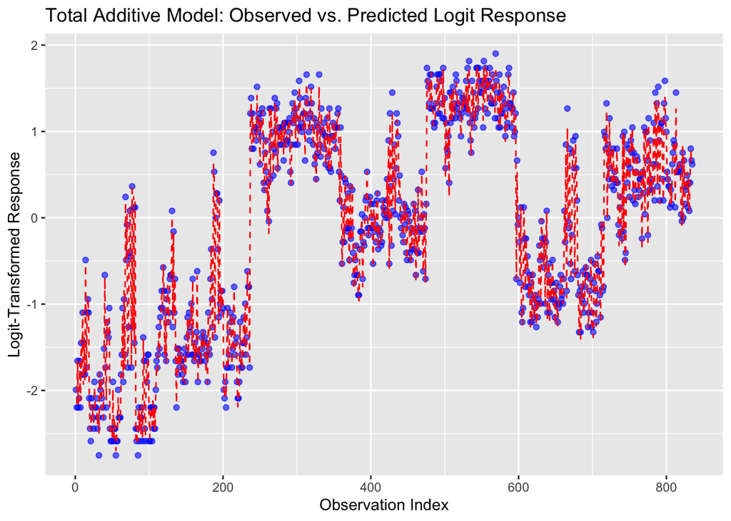

```r
interaction_model <- lm(y ~ (R + G + B + Hue) * (factor(Lightness) + factor(Saturation)), data = dfii)

dfii <- dfii %>%
  mutate(Index = 1:n(),
         predicted = predict(interaction_model))

ggplot(dfii, aes(x = Index)) +
  geom_point(aes(y = y), color = "blue", alpha = 0.6) +
  geom_line(aes(y = predicted), color = "red", linetype = "dashed") +
  labs(title = "Total Additive Model: Observed vs. Predicted Logit Response",
       x = "Observation Index",
       y = "Logit-Transformed Response")
```

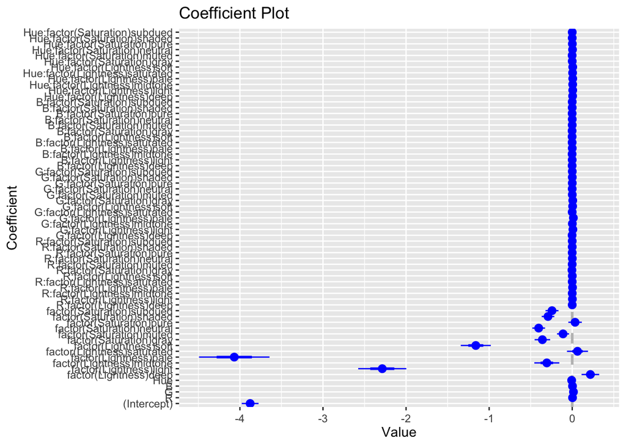

```r
coefplot(interaction_model)
```

```r
summary(interaction_model)
```

```
##
## Call:
## lm(formula = y ~ (R + G + B + Hue) * (factor(Lightness) + factor(Saturation)),
##     data = dfii)
##
## Residuals:
##       Min        1Q    Median        3Q       Max
## -0.259142 -0.035041 -0.003511  0.027300  0.250835
##
## Coefficients:
##                                  Estimate Std. Error t value Pr(>|t|)
## (Intercept)                    -3.877e+00  5.053e-02 -76.719  < 2e-16 ***
## R                               3.909e-03  1.819e-04  21.493  < 2e-16 ***
## G                               1.492e-02  2.754e-04  54.183  < 2e-16 ***
## B                               3.474e-03  3.765e-04   9.226  < 2e-16 ***
## Hue                            -6.730e-03  1.109e-03  -6.069 2.02e-09 ***
## factor(Lightness)deep           2.185e-01  5.308e-02   4.117 4.26e-05 ***
## factor(Lightness)light         -2.287e+00  1.448e-01 -15.791  < 2e-16 ***
## factor(Lightness)midtone       -3.056e-01  7.520e-02  -4.064 5.31e-05 ***
## factor(Lightness)pale          -4.068e+00  2.119e-01 -19.195  < 2e-16 ***
## factor(Lightness)saturated      6.354e-02  6.322e-02   1.005 0.315167
## factor(Lightness)soft          -1.161e+00  9.038e-02 -12.842  < 2e-16 ***
## factor(Saturation)gray         -3.591e-01  4.674e-02  -7.683 4.72e-14 ***
## factor(Saturation)muted        -1.104e-01  3.641e-02  -3.031 0.002522 **
## factor(Saturation)neutral      -4.037e-01  3.850e-02 -10.487  < 2e-16 ***
## factor(Saturation)pure          3.454e-02  4.047e-02   0.853 0.393738
## factor(Saturation)shaded       -2.915e-01  3.796e-02  -7.679 4.86e-14 ***
## factor(Saturation)subdued      -2.431e-01  3.898e-02  -6.238 7.31e-10 ***
## R:factor(Lightness)deep         3.739e-05  1.942e-04   0.193 0.847370
## R:factor(Lightness)light        2.140e-03  5.044e-04   4.243 2.47e-05 ***
## R:factor(Lightness)midtone      3.136e-04  2.762e-04   1.136 0.256430
## R:factor(Lightness)pale         3.743e-03  8.956e-04   4.180 3.26e-05 ***
## R:factor(Lightness)saturated   -1.606e-05  2.203e-04  -0.073 0.941904
## R:factor(Lightness)soft         1.017e-03  3.852e-04   2.641 0.008439 **
## R:factor(Saturation)gray       -3.265e-03  1.395e-03  -2.341 0.019475 *
## R:factor(Saturation)muted      -3.879e-04  2.373e-04  -1.635 0.102531
## R:factor(Saturation)neutral     1.256e-03  5.888e-04   2.134 0.033171 *
## R:factor(Saturation)pure       -2.367e-05  1.791e-04  -0.132 0.894881
## R:factor(Saturation)shaded      2.634e-04  4.143e-04   0.636 0.525149
## R:factor(Saturation)subdued     1.257e-04  3.146e-04   0.399 0.689732
```

[output cut: 27 more lines]

```
## Hue:factor(Lightness)pale       6.394e-03  1.214e-03   5.267 1.80e-07 ***
## Hue:factor(Lightness)saturated  4.404e-03  1.166e-03   3.777 0.000171 ***
## Hue:factor(Lightness)soft       6.267e-03  1.219e-03   5.140 3.48e-07 ***
## Hue:factor(Saturation)gray      1.987e-04  1.427e-03   0.139 0.889268
## Hue:factor(Saturation)muted    -8.850e-04  1.022e-03  -0.866 0.386646
## Hue:factor(Saturation)neutral   3.673e-03  1.140e-03   3.221 0.001330 **
## Hue:factor(Saturation)pure      1.616e-03  9.973e-04   1.620 0.105598
## Hue:factor(Saturation)shaded    2.363e-04  1.068e-03   0.221 0.824907
## Hue:factor(Saturation)subdued   3.258e-04  1.106e-03   0.294 0.768477
## ---
## Signif. codes:  0 '***' 0.001 '**' 0.01 '*' 0.05 '.' 0.1 ' ' 1
##
## Residual standard error: 0.0577 on 770 degrees of freedom
## Multiple R-squared:  0.9978, Adjusted R-squared:  0.9976
## F-statistic:  5477 on 64 and 770 DF,  p-value: < 2.2e-16
```

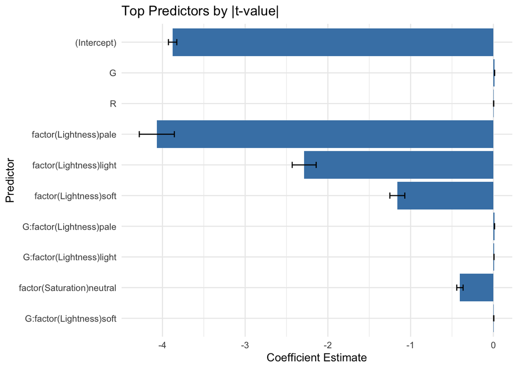

```r
plot_top_t_coefs(interaction_model)
```

• Add categorical inputs to all main effect and all pairwise interactions of continuous inputs

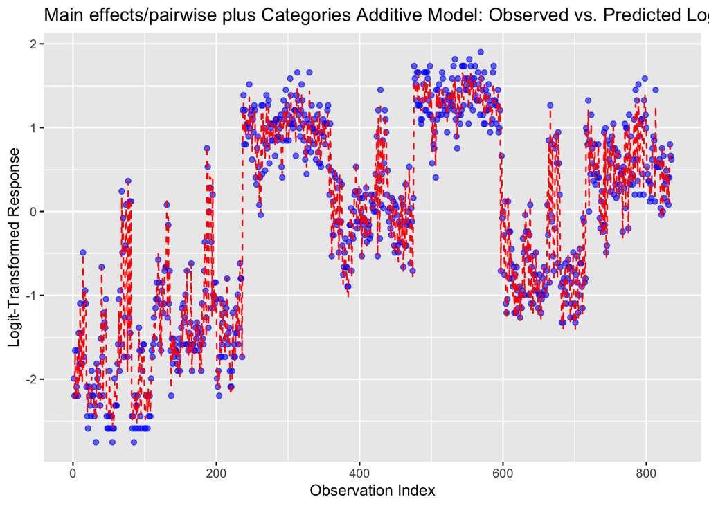

```r
pairwise_add_model <- lm(y ~ (R + G + B + Hue)^2 + factor(Lightness) + factor(Saturation), data = dfii)

dfii <- dfii %>%
  mutate(Index = 1:n(),
         predicted = predict(pairwise_add_model))

ggplot(dfii, aes(x = Index)) +
  geom_point(aes(y = y), color = "blue", alpha = 0.6) +
  geom_line(aes(y = predicted), color = "red", linetype = "dashed") +
  labs(title = "Main effects/pairwise plus Categories Additive Model: Observed vs. Predicted Logit Response",
       x = "Observation Index",
       y = "Logit-Transformed Response")
```

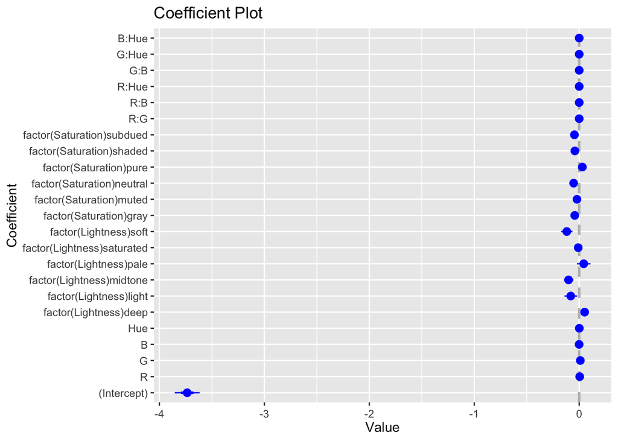

```r
coefplot(pairwise_add_model)
```

```r
summary(pairwise_add_model)
```

```
##
## Call:
## lm(formula = y ~ (R + G + B + Hue)^2 + factor(Lightness) + factor(Saturation),
##     data = dfii)
##
## Residuals:
##       Min        1Q    Median        3Q       Max
## -0.279514 -0.045883 -0.004634  0.042445  0.285820
##
## Coefficients:
##                              Estimate Std. Error t value Pr(>|t|)
## (Intercept)                -3.735e+00  5.930e-02 -62.988  < 2e-16 ***
## R                           4.889e-03  3.877e-04  12.610  < 2e-16 ***
## G                           1.078e-02  7.483e-04  14.401  < 2e-16 ***
## B                          -6.520e-04  8.841e-04  -0.738 0.461029
## Hue                         1.235e-03  1.607e-03   0.768 0.442481
## factor(Lightness)deep       5.195e-02  1.288e-02   4.035 5.98e-05 ***
## factor(Lightness)light     -8.022e-02  3.025e-02  -2.652 0.008166 **
## factor(Lightness)midtone   -1.012e-01  2.310e-02  -4.383 1.32e-05 ***
## factor(Lightness)pale       4.326e-02  3.219e-02   1.344 0.179377
## factor(Lightness)saturated -9.090e-03  1.803e-02  -0.504 0.614230
## factor(Lightness)soft      -1.182e-01  2.701e-02  -4.375 1.37e-05 ***
## factor(Saturation)gray     -4.236e-02  1.348e-02  -3.142 0.001741 **
## factor(Saturation)muted    -2.128e-02  1.013e-02  -2.101 0.035971 *
## factor(Saturation)neutral  -5.285e-02  1.118e-02  -4.727 2.69e-06 ***
## factor(Saturation)pure      3.002e-02  1.056e-02   2.842 0.004597 **
## factor(Saturation)shaded   -4.114e-02  1.080e-02  -3.810 0.000149 ***
## factor(Saturation)subdued  -4.519e-02  1.041e-02  -4.339 1.61e-05 ***
## R:G                         1.161e-05  2.023e-06   5.742 1.32e-08 ***
## R:B                        -4.018e-06  2.765e-06  -1.453 0.146487
## R:Hue                      -8.431e-05  1.474e-05  -5.720 1.50e-08 ***
## G:B                         2.297e-05  2.683e-06   8.559  < 2e-16 ***
## G:Hue                       6.392e-05  2.032e-05   3.146 0.001717 **
## B:Hue                       1.531e-05  2.321e-05   0.660 0.509713
## ---
## Signif. codes:  0 '***' 0.001 '**' 0.01 '*' 0.05 '.' 0.1 ' ' 1
##
## Residual standard error: 0.07895 on 812 degrees of freedom
## Multiple R-squared:  0.9957, Adjusted R-squared:  0.9956
## F-statistic:  8494 on 22 and 812 DF,  p-value: < 2.2e-16
```

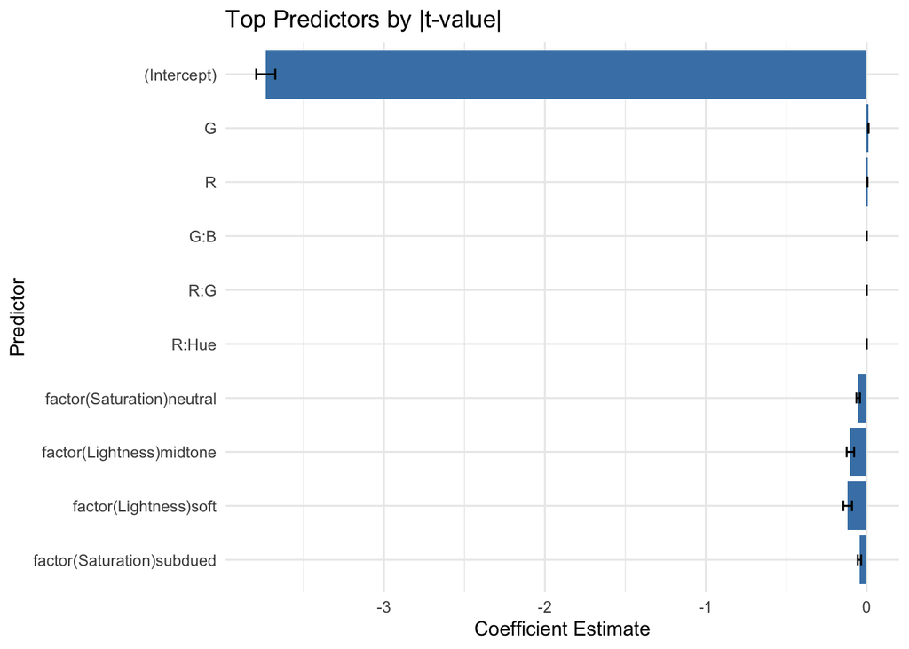

```r
plot_top_t_coefs(pairwise_add_model)
```

•Interaction of the categorical inputs with all main effect and all pairwise interactions of continuous inputs

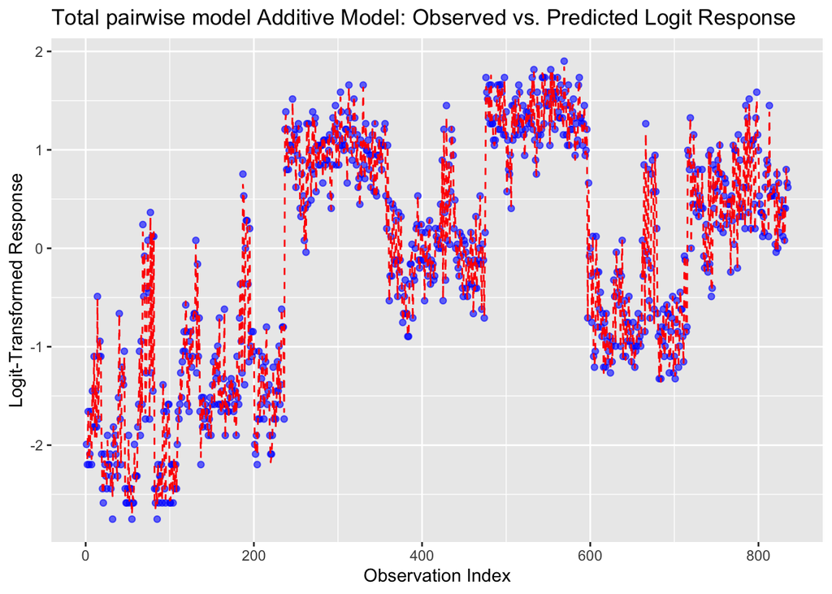

```r
total_model <- lm(y ~ (R + G + B + Hue)^2 * (factor(Lightness) + factor(Saturation)), data = dfii)

dfii <- dfii %>%
  mutate(Index = 1:n(),
         predicted = predict(total_model))

ggplot(dfii, aes(x = Index)) +
  geom_point(aes(y = y), color = "blue", alpha = 0.6) +
  geom_line(aes(y = predicted), color = "red", linetype = "dashed") +
  labs(title = "Total pairwise model Additive Model: Observed vs. Predicted Logit Response",
       x = "Observation Index",
       y = "Logit-Transformed Response")
```

[figure not shown]

```r
coefplot(total_model)
```

```r
summary(total_model)
```

```
##
## Call:
## lm(formula = y ~ (R + G + B + Hue)^2 * (factor(Lightness) + factor(Saturation)),
##     data = dfii)
##
## Residuals:
##       Min        1Q    Median        3Q       Max
## -0.233973 -0.023247 -0.001102  0.022124  0.201412
##
## Coefficients:
##                                    Estimate Std. Error t value Pr(>|t|)
## (Intercept)                      -4.782e+00  3.131e-01 -15.271  < 2e-16 ***
## R                                 8.432e-03  1.890e-03   4.461 9.53e-06 ***
## G                                 1.737e-02  2.291e-03   7.582 1.10e-13 ***
## B                                 9.959e-03  2.059e-03   4.837 1.63e-06 ***
## Hue                               8.036e-03  1.264e-02   0.636 0.525200
## factor(Lightness)deep             4.939e-01  2.378e-01   2.077 0.038131 *
## factor(Lightness)light            1.102e+01  1.708e+00   6.450 2.10e-10 ***
## factor(Lightness)midtone          3.742e+00  4.747e-01   7.883 1.25e-14 ***
## factor(Lightness)pale             2.460e+01  3.356e+00   7.330 6.45e-13 ***
## factor(Lightness)saturated        2.235e+00  3.115e-01   7.175 1.86e-12 ***
## factor(Lightness)soft             6.570e+00  7.647e-01   8.591  < 2e-16 ***
## factor(Saturation)gray           -1.148e-01  2.797e-01  -0.411 0.681526
## factor(Saturation)muted          -3.031e-01  2.408e-01  -1.259 0.208560
## factor(Saturation)neutral        -1.512e-01  2.568e-01  -0.589 0.556208
## factor(Saturation)pure           -1.225e-01  3.184e-01  -0.385 0.700495
## factor(Saturation)shaded         -6.223e-02  2.535e-01  -0.245 0.806191
## factor(Saturation)subdued        -3.923e-01  2.611e-01  -1.503 0.133386
## R:G                              -1.634e-05  6.036e-06  -2.706 0.006967 **
## R:B                              -1.741e-05  8.436e-06  -2.064 0.039398 *
## R:Hue                            -3.375e-05  6.661e-05  -0.507 0.612528
## G:B                              -1.677e-05  1.342e-05  -1.249 0.211982
## G:Hue                             4.219e-05  5.500e-05   0.767 0.443352
## B:Hue                            -1.305e-04  7.460e-05  -1.749 0.080692 .
## R:factor(Lightness)deep          -7.922e-04  9.529e-04  -0.831 0.406072
## R:factor(Lightness)light         -3.478e-02  7.982e-03  -4.357 1.52e-05 ***
## R:factor(Lightness)midtone       -1.259e-02  2.093e-03  -6.016 2.90e-09 ***
## R:factor(Lightness)pale          -6.586e-02  1.990e-02  -3.309 0.000985 ***
## R:factor(Lightness)saturated     -8.552e-03  1.366e-03  -6.260 6.76e-10 ***
## R:factor(Lightness)soft          -1.965e-02  3.593e-03  -5.467 6.39e-08 ***
```

[output cut: 105 more lines]

```
## B:Hue:factor(Lightness)pale      -2.002e-04  1.539e-04  -1.301 0.193803
## B:Hue:factor(Lightness)saturated  1.223e-04  6.208e-05   1.971 0.049152 *
## B:Hue:factor(Lightness)soft      -7.236e-05  8.642e-05  -0.837 0.402694
## B:Hue:factor(Saturation)gray      2.232e-04  1.531e-04   1.458 0.145257
## B:Hue:factor(Saturation)muted     3.204e-05  5.489e-05   0.584 0.559617
## B:Hue:factor(Saturation)neutral   1.738e-04  8.440e-05   2.059 0.039866 *
## B:Hue:factor(Saturation)pure     -4.786e-05  6.073e-05  -0.788 0.430981
## B:Hue:factor(Saturation)shaded    1.730e-05  7.242e-05   0.239 0.811232
## B:Hue:factor(Saturation)subdued   2.092e-04  6.741e-05   3.103 0.001996 **
## ---
## Signif. codes:  0 '***' 0.001 '**' 0.01 '*' 0.05 '.' 0.1 ' ' 1
##
## Residual standard error: 0.04486 on 692 degrees of freedom
## Multiple R-squared:  0.9988, Adjusted R-squared:  0.9986
## F-statistic:  4089 on 142 and 692 DF,  p-value: < 2.2e-16
```

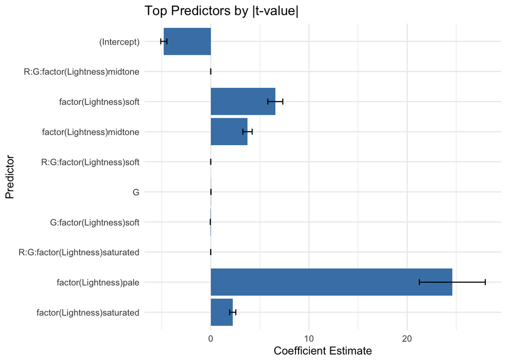

```r
plot_top_t_coefs(total_model)
```

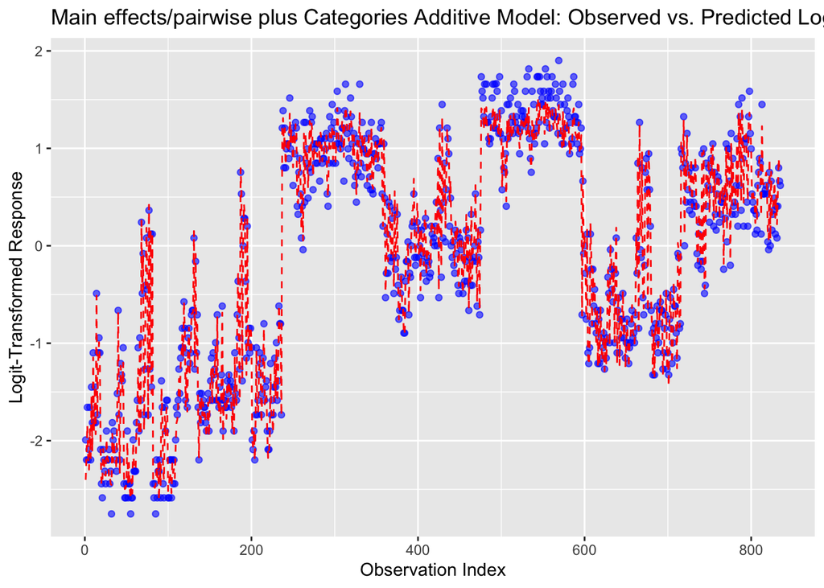

```r
##observationally, it seemed that red related to logit response potentially non-linearly (quadratic), and the other colors related linearly

##the saturation level seemed to add strength to the linear relationship, where the lightness level seemed to give clusters (general ranges)

my_model_1 <- lm(y ~ (I(R^2) * I(R)) + G + B + factor(Saturation), data = dfii)

dfii <- dfii %>%
  mutate(Index = 1:n(),
         predicted = predict(my_model_1))

ggplot(dfii, aes(x = Index)) +
  geom_point(aes(y = y), color = "blue", alpha = 0.6) +
  geom_line(aes(y = predicted), color = "red", linetype = "dashed") +
  labs(title = "Main effects/pairwise plus Categories Additive Model: Observed vs. Predicted Logit Response",
       x = "Observation Index",
       y = "Logit-Transformed Response")
```

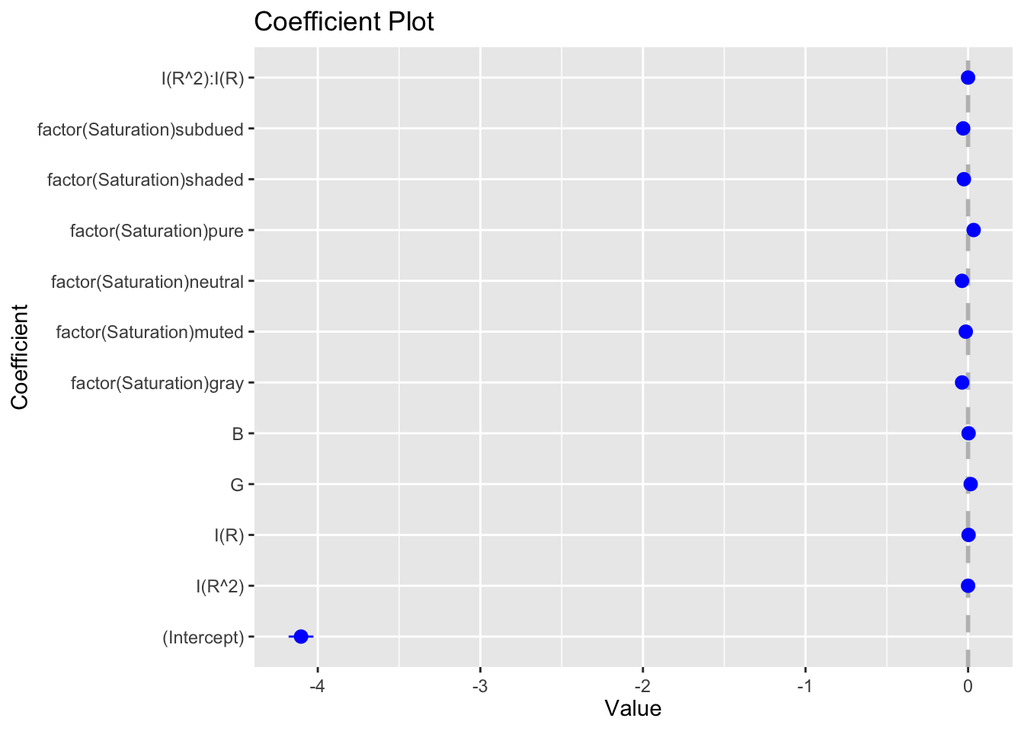

```r
coefplot(my_model_1)
```

```r
summary(my_model_1)
```

```
##
## Call:
## lm(formula = y ~ (I(R^2) * I(R)) + G + B + factor(Saturation),
##     data = dfii)
##
## Residuals:
##      Min       1Q   Median       3Q      Max
## -0.30154 -0.07786 -0.01031  0.05893  0.45640
##
## Coefficients:
##                             Estimate Std. Error  t value Pr(>|t|)
## (Intercept)               -4.103e+00  3.816e-02 -107.514  < 2e-16 ***
## I(R^2)                    -6.366e-06  6.903e-06   -0.922 0.356704
## I(R)                       3.073e-03  8.726e-04    3.522 0.000452 ***
## G                          1.594e-02  1.859e-04   85.752  < 2e-16 ***
## B                          3.087e-03  1.301e-04   23.736  < 2e-16 ***
## factor(Saturation)gray    -3.681e-02  1.680e-02   -2.191 0.028736 *
## factor(Saturation)muted   -1.425e-02  1.453e-02   -0.981 0.327111
## factor(Saturation)neutral -3.749e-02  1.493e-02   -2.512 0.012202 *
## factor(Saturation)pure     3.418e-02  1.457e-02    2.346 0.019191 *
## factor(Saturation)shaded  -2.566e-02  1.476e-02   -1.738 0.082501 .
## factor(Saturation)subdued -3.012e-02  1.468e-02   -2.053 0.040426 *
## I(R^2):I(R)                4.807e-08  1.615e-08    2.977 0.003001 **
## ---
## Signif. codes:  0 '***' 0.001 '**' 0.01 '*' 0.05 '.' 0.1 ' ' 1
##
## Residual standard error: 0.1144 on 823 degrees of freedom
## Multiple R-squared:  0.9908, Adjusted R-squared:  0.9907
## F-statistic:  8050 on 11 and 823 DF,  p-value: < 2.2e-16
```

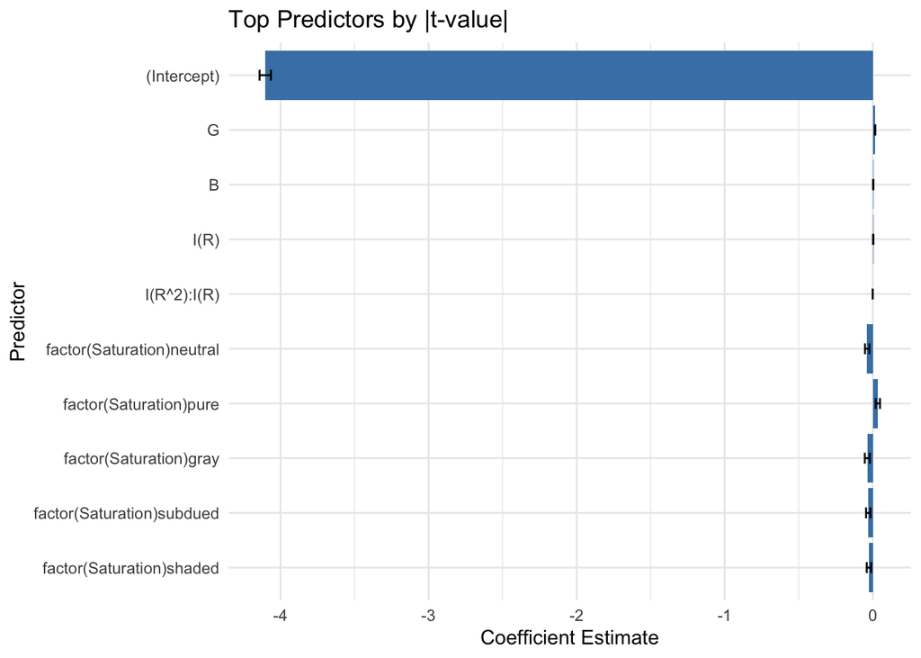

```r
plot_top_t_coefs(my_model_1)
```

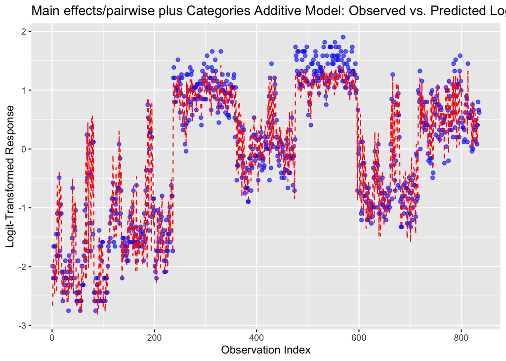

```r
#I saw particularly strong linear relations between logit response and green values, and I saw linear patterns appear when stratified by saturation, so let's do a model just looking at that
#Simplicity here could be an advantage of this model, it will not likely suffer from overfitting (still must do other tests to verify still)

my_model_2 <- lm(y ~  G * factor(Saturation), data = dfii)

dfii <- dfii %>%
  mutate(Index = 1:n(),
         predicted = predict(my_model_2))

ggplot(dfii, aes(x = Index)) +
  geom_point(aes(y = y), color = "blue", alpha = 0.6) +
  geom_line(aes(y = predicted), color = "red", linetype = "dashed") +
  labs(title = "Main effects/pairwise plus Categories Additive Model: Observed vs. Predicted Logit Response",
       x = "Observation Index",
       y = "Logit-Transformed Response")
```

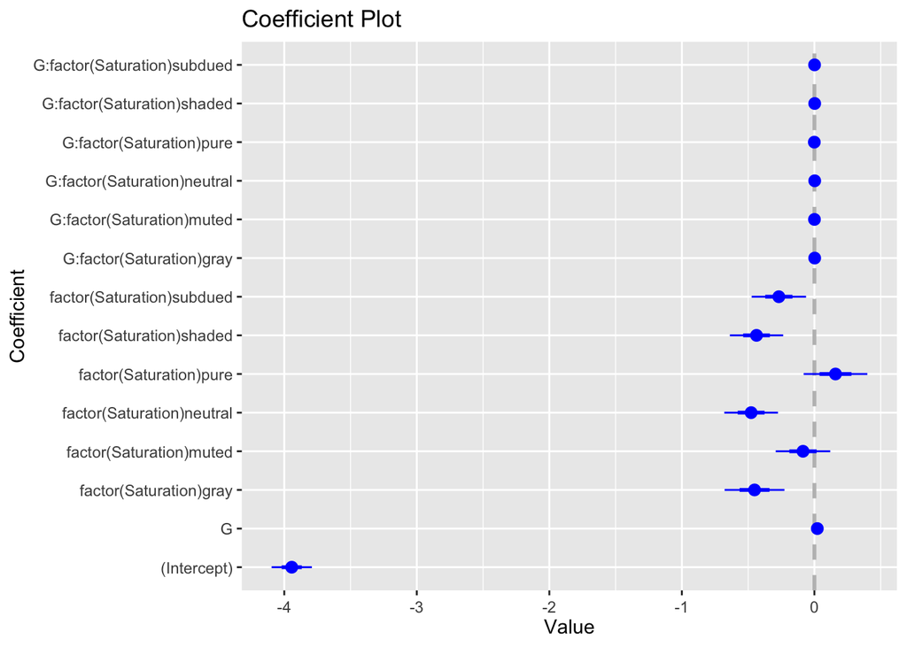

```r
coefplot(my_model_2)
```

```r
summary(my_model_2)
```

```
##
## Call:
## lm(formula = y ~ G * factor(Saturation), data = dfii)
##
## Residuals:
##      Min       1Q   Median       3Q      Max
## -0.75797 -0.12111  0.00544  0.13206  0.77295
##
## Coefficients:
##                               Estimate Std. Error t value Pr(>|t|)
## (Intercept)                 -3.9435301  0.0759382 -51.931  < 2e-16 ***
## G                            0.0219860  0.0004057  54.197  < 2e-16 ***
## factor(Saturation)gray      -0.4516814  0.1129005  -4.001 6.89e-05 ***
## factor(Saturation)muted     -0.0860596  0.1028680  -0.837  0.40306
## factor(Saturation)neutral   -0.4773030  0.1011782  -4.717 2.81e-06 ***
## factor(Saturation)pure       0.1592244  0.1201398   1.325  0.18543
## factor(Saturation)shaded    -0.4367292  0.1005291  -4.344 1.57e-05 ***
## factor(Saturation)subdued   -0.2682844  0.1026738  -2.613  0.00914 **
## G:factor(Saturation)gray     0.0020779  0.0006363   3.265  0.00114 **
## G:factor(Saturation)muted    0.0003734  0.0005582   0.669  0.50378
## G:factor(Saturation)neutral  0.0022942  0.0005512   4.162 3.48e-05 ***
## G:factor(Saturation)pure    -0.0006971  0.0006123  -1.138  0.25525
## G:factor(Saturation)shaded   0.0021866  0.0005491   3.982 7.42e-05 ***
## G:factor(Saturation)subdued  0.0012088  0.0005613   2.154  0.03156 *
## ---
## Signif. codes:  0 '***' 0.001 '**' 0.01 '*' 0.05 '.' 0.1 ' ' 1
##
## Residual standard error: 0.216 on 821 degrees of freedom
## Multiple R-squared:  0.9673, Adjusted R-squared:  0.9668
## F-statistic:  1866 on 13 and 821 DF,  p-value: < 2.2e-16
```

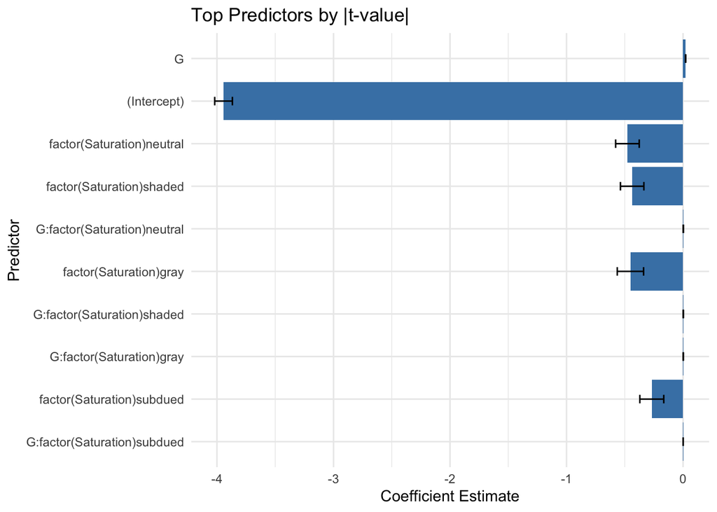

```r
plot_top_t_coefs(my_model_2)
```

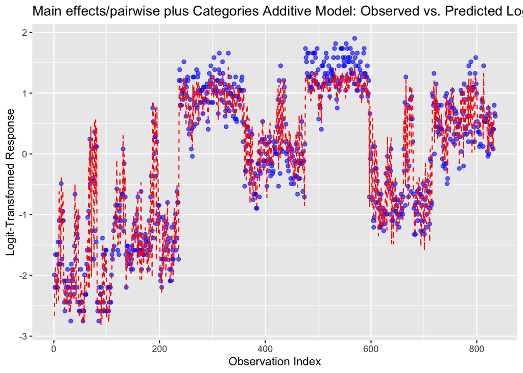

```r
## modeling the Hue as a circular feature
## The Hue variable is inherently circular (0–360 degrees), meaning that 0 and 360 degrees are similar.
##Linear treatment of Hue doesn't capture its cyclical nature.

my_model_3 <- lm(y ~ sinpi(Hue/180) + cospi(Hue/180) +
                   G + B + factor(Saturation) +
                   sinpi(Hue/180):factor(Saturation) +
                   cospi(Hue/180):factor(Saturation),
                 data = dfii)

dfii <- dfii %>%
  mutate(Index = 1:n(),
         predicted = predict(my_model_2))

ggplot(dfii, aes(x = Index)) +
  geom_point(aes(y = y), color = "blue", alpha = 0.6) +
  geom_line(aes(y = predicted), color = "red", linetype = "dashed") +
  labs(title = "Main effects/pairwise plus Categories Additive Model: Observed vs. Predicted Logit Response",
       x = "Observation Index",
       y = "Logit-Transformed Response")
```

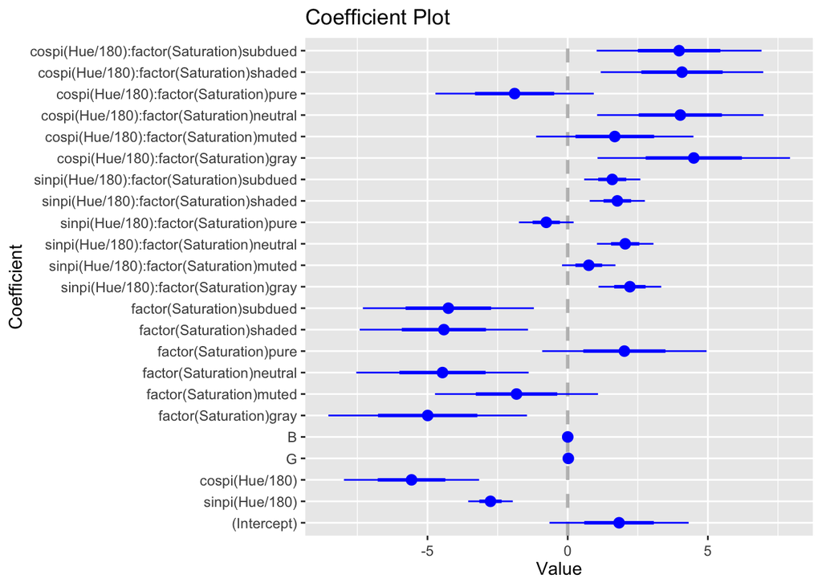

```r
coefplot(my_model_3)
```

```r
summary(my_model_3)
```

```
##
## Call:
## lm(formula = y ~ sinpi(Hue/180) + cospi(Hue/180) + G + B + factor(Saturation) +
##     sinpi(Hue/180):factor(Saturation) + cospi(Hue/180):factor(Saturation),
##     data = dfii)
##
## Residuals:
##      Min       1Q   Median       3Q      Max
## -0.47576 -0.10687 -0.00943  0.09616  0.54608
##
## Coefficients:
##                                            Estimate Std. Error t value Pr(>|t|)
## (Intercept)                               1.8324312  1.2407477   1.477 0.140096
## sinpi(Hue/180)                           -2.7532149  0.3975029  -6.926 8.79e-12
## cospi(Hue/180)                           -5.5695106  1.2051456  -4.621 4.43e-06
## G                                         0.0218718  0.0003351  65.275  < 2e-16
## B                                         0.0018277  0.0003102   5.892 5.60e-09
## factor(Saturation)gray                   -4.9932600  1.7706096  -2.820 0.004918
## factor(Saturation)muted                  -1.8253679  1.4526582  -1.257 0.209270
## factor(Saturation)neutral                -4.4657146  1.5368966  -2.906 0.003764
## factor(Saturation)pure                    2.0219121  1.4659031   1.379 0.168184
## factor(Saturation)shaded                 -4.4164398  1.5007738  -2.943 0.003345
## factor(Saturation)subdued                -4.2562526  1.5245211  -2.792 0.005364
## sinpi(Hue/180):factor(Saturation)gray     2.2182923  0.5595772   3.964 8.01e-05
## sinpi(Hue/180):factor(Saturation)muted    0.7514735  0.4759954   1.579 0.114785
## sinpi(Hue/180):factor(Saturation)neutral  2.0514356  0.5038866   4.071 5.13e-05
## sinpi(Hue/180):factor(Saturation)pure    -0.7642550  0.4875095  -1.568 0.117347
## sinpi(Hue/180):factor(Saturation)shaded   1.7698145  0.4915474   3.600 0.000337
## sinpi(Hue/180):factor(Saturation)subdued  1.5893711  0.5003423   3.177 0.001547
## cospi(Hue/180):factor(Saturation)gray     4.4971539  1.7156724   2.621 0.008925
## cospi(Hue/180):factor(Saturation)muted    1.6798834  1.4025161   1.198 0.231358
## cospi(Hue/180):factor(Saturation)neutral  4.0169112  1.4831905   2.708 0.006905
## cospi(Hue/180):factor(Saturation)pure    -1.8934471  1.4118230  -1.341 0.180251
## cospi(Hue/180):factor(Saturation)shaded   4.0768977  1.4492416   2.813 0.005025
## cospi(Hue/180):factor(Saturation)subdued  3.9731128  1.4704779   2.702 0.007038
##
## (Intercept)
## sinpi(Hue/180)                           ***
## cospi(Hue/180)                           ***
## G                                        ***
```

[output cut: 10 more lines]

```
## sinpi(Hue/180):factor(Saturation)pure
## sinpi(Hue/180):factor(Saturation)shaded  ***
## sinpi(Hue/180):factor(Saturation)subdued **
## cospi(Hue/180):factor(Saturation)gray    **
## cospi(Hue/180):factor(Saturation)muted
## cospi(Hue/180):factor(Saturation)neutral **
## cospi(Hue/180):factor(Saturation)pure
## cospi(Hue/180):factor(Saturation)shaded  **
## cospi(Hue/180):factor(Saturation)subdued **
## ---
## Signif. codes:  0 '***' 0.001 '**' 0.01 '*' 0.05 '.' 0.1 ' ' 1
##
## Residual standard error: 0.1691 on 812 degrees of freedom
## Multiple R-squared:  0.9802, Adjusted R-squared:  0.9796
## F-statistic:  1823 on 22 and 812 DF,  p-value: < 2.2e-16
```

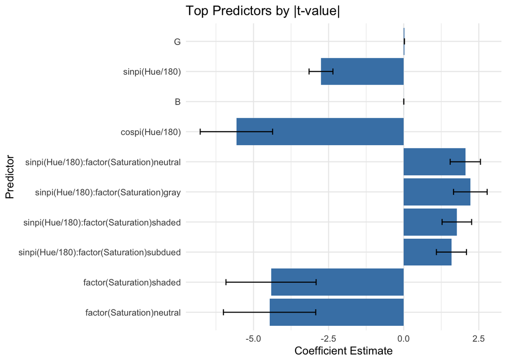

```r
plot_top_t_coefs(my_model_3)
```

```r
rmse <- function(actual, predicted) {
  sqrt(mean((actual - predicted)^2))
}

mae <- function(actual, predicted) {
  mean(abs(actual - predicted))
}

# List of models
models <- list(
  intercept_only = interceptonly,
  categorical    = cat_model,
  continuous     = cont_model,
  additive       = tot_model,
  interaction    = interaction_model,
  pairwise_add   = pairwise_add_model,
  total_model    = total_model,
  my_model_1     = my_model_1,
  my_model_2     = my_model_2,
  my_model_3     = my_model_3
)

# Create empty data frame to store results
model_scores <- data.frame(Model = character(),
                           RMSE = numeric(),
                           R2 = numeric(),
                           MAE = numeric(),
                           stringsAsFactors = FALSE)

# Loop through each model and calculate metrics
for (name in names(models)) {
  model <- models[[name]]
  preds <- predict(model, newdata = dfii)
  actual <- dfii$y

  model_scores <- bind_rows(model_scores, tibble(
    Model = name,
    RMSE = rmse(actual, preds),
    R2   = summary(model)$r.squared,
    MAE  = mae(actual, preds)
  ))
}

# Rank by RMSE (lower is better)
model_scores <- model_scores %>% arrange(RMSE)

# Print performance comparison
print(model_scores)
```

```
##             Model       RMSE        R2        MAE
## 1     total_model 0.04083912 0.9988095 0.03011403
## 2     interaction 0.05541224 0.9978083 0.04143944
## 3    pairwise_add 0.07785346 0.9956736 0.05888459
## 4        additive 0.08771520 0.9945082 0.06575639
## 5      my_model_1 0.11358519 0.9907911 0.08759927
## 6      continuous 0.12909848 0.9881038 0.10142118
## 7      my_model_3 0.16674087 0.9801550 0.12911321
## 8      my_model_2 0.21413942 0.9672690 0.16261942
## 9     categorical 0.40203000 0.8846326 0.31020433
## 10 intercept_only 1.18363270 0.0000000 1.01677422
```

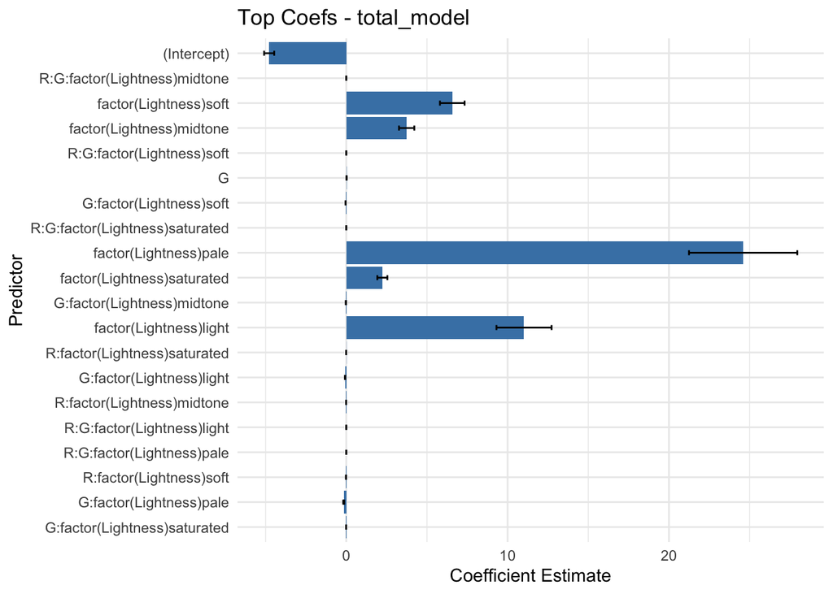

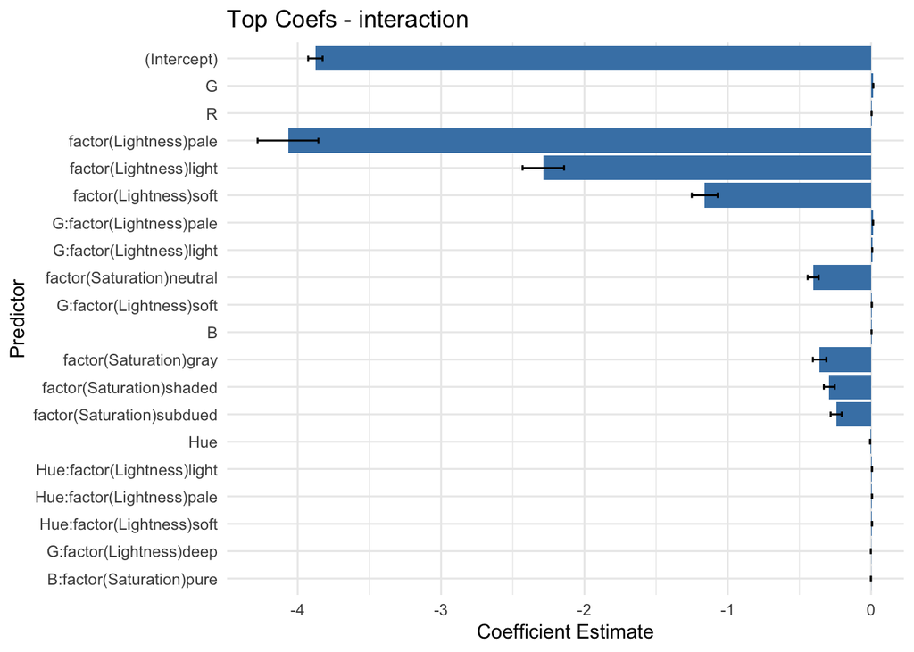

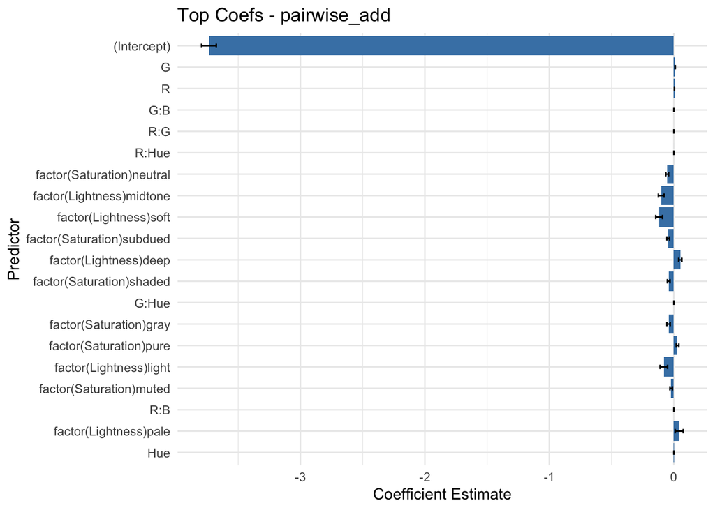

```r
# Top 3 models
top_3 <- model_scores %>% slice(1:3) %>% pull(Model)

# Plot top 3 coefficients
top_plots <- lapply(top_3, function(name) {
  model <- models[[name]]
  plot_top_t_coefs(model, top_n = 20, title = paste("Top Coefs -", name))
})

# Display plots
top_plots
```

When looking at the RMSE, R2, and MAE, the unanimous order of the best three models are total_model, interaction, and pairwise_add, in that order.

Almost universally, the categorical variables seem to play an important role in modeling logit response. While the colors do appear in these top models with significance, they have values that are small and potentially won’t contribute to the overall model to the degree that the categorical variables do. We will really see what inputs are relevant when we cross validate and use a bayesian approach.

```r
# Bayesian Model 1: Best model is interaction. This is because total_model didn't converge, so I will use the next best model in terms of RMSE, R2, and MAE, which is interaction_model.
bayes_interaction <- stan_glm(
  formula = y ~ (R + G + B + Hue) * (factor(Lightness) + factor(Saturation)),
  data = dfii,
  family = gaussian(),
  prior = normal(0, 10, autoscale = TRUE),
  prior_intercept = normal(0, 10, autoscale = TRUE),
  chains = 4,
  iter = 2000,
  seed = 12345
)
print(summary(bayes_interaction))
```

```
##
## Model Info:
##  function:     stan_glm
##  family:       gaussian [identity]
##  formula:      y ~ (R + G + B + Hue) * (factor(Lightness) + factor(Saturation))
##  algorithm:    sampling
##  sample:       4000 (posterior sample size)
##  priors:       see help('prior_summary')
##  observations: 835
##  predictors:   65
##
## Estimates:
##                                  mean   sd   10%   50%   90%
## (Intercept)                    -3.9    0.1 -3.9  -3.9  -3.8
## R                               0.0    0.0  0.0   0.0   0.0
## G                               0.0    0.0  0.0   0.0   0.0
## B                               0.0    0.0  0.0   0.0   0.0
## Hue                             0.0    0.0  0.0   0.0   0.0
## factor(Lightness)deep           0.2    0.1  0.1   0.2   0.3
## factor(Lightness)light         -2.3    0.1 -2.5  -2.3  -2.1
## factor(Lightness)midtone       -0.3    0.1 -0.4  -0.3  -0.2
## factor(Lightness)pale          -4.1    0.2 -4.3  -4.1  -3.8
## factor(Lightness)saturated      0.1    0.1  0.0   0.1   0.1
## factor(Lightness)soft          -1.2    0.1 -1.3  -1.2  -1.0
## factor(Saturation)gray         -0.4    0.0 -0.4  -0.4  -0.3
## factor(Saturation)muted        -0.1    0.0 -0.2  -0.1  -0.1
## factor(Saturation)neutral      -0.4    0.0 -0.5  -0.4  -0.4
## factor(Saturation)pure          0.0    0.0  0.0   0.0   0.1
## factor(Saturation)shaded       -0.3    0.0 -0.3  -0.3  -0.2
## factor(Saturation)subdued      -0.2    0.0 -0.3  -0.2  -0.2
## R:factor(Lightness)deep         0.0    0.0  0.0   0.0   0.0
## R:factor(Lightness)light        0.0    0.0  0.0   0.0   0.0
## R:factor(Lightness)midtone      0.0    0.0  0.0   0.0   0.0
## R:factor(Lightness)pale         0.0    0.0  0.0   0.0   0.0
## R:factor(Lightness)saturated    0.0    0.0  0.0   0.0   0.0
## R:factor(Lightness)soft         0.0    0.0  0.0   0.0   0.0
## R:factor(Saturation)gray        0.0    0.0  0.0   0.0   0.0
## R:factor(Saturation)muted       0.0    0.0  0.0   0.0   0.0
## R:factor(Saturation)neutral     0.0    0.0  0.0   0.0   0.0
## R:factor(Saturation)pure        0.0    0.0  0.0   0.0   0.0
```

[output cut: 103 more lines]

```
## Hue:factor(Lightness)midtone   0.0  1.0  3492
## Hue:factor(Lightness)pale      0.0  1.0  2528
## Hue:factor(Lightness)saturated 0.0  1.0  3321
## Hue:factor(Lightness)soft      0.0  1.0  3501
## Hue:factor(Saturation)gray     0.0  1.0  3332
## Hue:factor(Saturation)muted    0.0  1.0  4740
## Hue:factor(Saturation)neutral  0.0  1.0  3916
## Hue:factor(Saturation)pure     0.0  1.0  4564
## Hue:factor(Saturation)shaded   0.0  1.0  4369
## Hue:factor(Saturation)subdued  0.0  1.0  4690
## sigma                          0.0  1.0  2651
## mean_PPD                       0.0  1.0  4483
## log-posterior                  0.2  1.0  1364
##
## For each parameter, mcse is Monte Carlo standard error, n_eff is a crude measure of effective sample size, and Rhat is the potential scale reduction factor on split chains (at convergence Rhat=1).
```

```r
# Reason for choice of my_model_3:
# my_model_3 is chosen because it is the only model that attempts to understand hue in a circular manner. If a real relationship exists there, we will be able to understand it well with a bayesian linear model. Most of the other models contain many of the same terms, just including or excluding various terms from total_model, but my_model_3 has features that are unique.
#------------------------------------------------
bayes_my3 <- stan_glm(
  formula = y ~ sinpi(Hue/180) + cospi(Hue/180) +
                   G + B + factor(Saturation) +
                   sinpi(Hue/180):factor(Saturation) +
                   cospi(Hue/180):factor(Saturation),
  data = dfii,
  family = gaussian(),
  prior = normal(0, 10, autoscale = TRUE),
  prior_intercept = normal(0, 10, autoscale = TRUE),
  chains = 4,
  iter = 2000,
  seed = 54321
)
# Print a summary of the Bayesian my_model_1
print(summary(bayes_my3))
```

```
##
## Model Info:
##  function:     stan_glm
##  family:       gaussian [identity]
##  formula:      y ~ sinpi(Hue/180) + cospi(Hue/180) + G + B + factor(Saturation) +
##     sinpi(Hue/180):factor(Saturation) + cospi(Hue/180):factor(Saturation)
##  algorithm:    sampling
##  sample:       4000 (posterior sample size)
##  priors:       see help('prior_summary')
##  observations: 835
##  predictors:   23
##
## Estimates:
##                                            mean   sd   10%   50%   90%
## (Intercept)                               1.7    1.3  0.1   1.7   3.3
## sinpi(Hue/180)                           -2.7    0.4 -3.2  -2.7  -2.2
## cospi(Hue/180)                           -5.5    1.2 -7.0  -5.5  -3.9
## G                                         0.0    0.0  0.0   0.0   0.0
## B                                         0.0    0.0  0.0   0.0   0.0
## factor(Saturation)gray                   -4.9    1.8 -7.1  -4.9  -2.6
## factor(Saturation)muted                  -1.7    1.5 -3.6  -1.7   0.2
## factor(Saturation)neutral                -4.3    1.5 -6.3  -4.3  -2.4
## factor(Saturation)pure                    2.1    1.5  0.3   2.1   4.0
## factor(Saturation)shaded                 -4.3    1.5 -6.3  -4.3  -2.3
## factor(Saturation)subdued                -4.1    1.5 -6.1  -4.1  -2.2
## sinpi(Hue/180):factor(Saturation)gray     2.2    0.6  1.5   2.2   2.9
## sinpi(Hue/180):factor(Saturation)muted    0.7    0.5  0.1   0.7   1.3
## sinpi(Hue/180):factor(Saturation)neutral  2.0    0.5  1.4   2.0   2.7
## sinpi(Hue/180):factor(Saturation)pure    -0.8    0.5 -1.4  -0.8  -0.2
## sinpi(Hue/180):factor(Saturation)shaded   1.7    0.5  1.1   1.7   2.4
## sinpi(Hue/180):factor(Saturation)subdued  1.6    0.5  0.9   1.6   2.2
## cospi(Hue/180):factor(Saturation)gray     4.4    1.7  2.2   4.4   6.6
## cospi(Hue/180):factor(Saturation)muted    1.6    1.4 -0.3   1.6   3.4
## cospi(Hue/180):factor(Saturation)neutral  3.9    1.5  2.0   3.9   5.8
## cospi(Hue/180):factor(Saturation)pure    -2.0    1.4 -3.8  -2.0  -0.2
## cospi(Hue/180):factor(Saturation)shaded   4.0    1.5  2.1   4.0   5.8
## cospi(Hue/180):factor(Saturation)subdued  3.9    1.5  2.0   3.8   5.8
## sigma                                     0.2    0.0  0.2   0.2   0.2
##
## Fit Diagnostics:
```

[output cut: 20 more lines]

```
## sinpi(Hue/180):factor(Saturation)neutral 0.0  1.0  1011
## sinpi(Hue/180):factor(Saturation)pure    0.0  1.0  1276
## sinpi(Hue/180):factor(Saturation)shaded  0.0  1.0  1067
## sinpi(Hue/180):factor(Saturation)subdued 0.0  1.0  1063
## cospi(Hue/180):factor(Saturation)gray    0.1  1.0  1132
## cospi(Hue/180):factor(Saturation)muted   0.0  1.0  1060
## cospi(Hue/180):factor(Saturation)neutral 0.0  1.0   978
## cospi(Hue/180):factor(Saturation)pure    0.0  1.0  1235
## cospi(Hue/180):factor(Saturation)shaded  0.0  1.0  1066
## cospi(Hue/180):factor(Saturation)subdued 0.0  1.0  1052
## sigma                                    0.0  1.0  4682
## mean_PPD                                 0.0  1.0  4780
## log-posterior                            0.1  1.0  1578
##
## For each parameter, mcse is Monte Carlo standard error, n_eff is a crude measure of effective sample size, and Rhat is the potential scale reduction factor on split chains (at convergence Rhat=1).
```

```r
# Here we use posterior_predict() to extract 1000 draws for each observation,
# then average over draws to get point predictions.
pred_interaction <- apply(posterior_predict(bayes_interaction, draws = 1000), 2, mean)
pred_my3  <- apply(posterior_predict(bayes_my3, draws = 1000), 2, mean)

#----------------------------
# Define functions to compute performance metrics
#----------------------------
rmse <- function(actual, predicted) {
  sqrt(mean((actual - predicted)^2))
}

mae <- function(actual, predicted) {
  mean(abs(actual - predicted))
}

r2 <- function(actual, predicted) {
  1 - sum((actual - predicted)^2) / sum((actual - mean(actual))^2)
}

# Compute Metrics for Each Model
metrics_total <- c(
  RMSE = rmse(dfii$y, pred_interaction),
  MAE  = mae(dfii$y, pred_interaction),
  R2   = r2(dfii$y, pred_interaction)
)

metrics_my1 <- c(
  RMSE = rmse(dfii$y, pred_my3),
  MAE  = mae(dfii$y, pred_my3),
  R2   = r2(dfii$y, pred_my3)
)

# Combine the results in a data frame
metrics_df <- tibble(
  Model = c("Bayesian Interaction Model", "Bayesian my_model_3"),
  RMSE  = c(metrics_total["RMSE"], metrics_my1["RMSE"]),
  MAE   = c(metrics_total["MAE"], metrics_my1["MAE"]),
  R2    = c(metrics_total["R2"], metrics_my1["R2"])
)

#----------------------------
# Display the Table
#----------------------------
print(metrics_df)
```

```
## # A tibble: 2 × 4
##   Model                        RMSE    MAE    R2
##   <chr>                       <dbl>  <dbl> <dbl>
## 1 Bayesian Interaction Model 0.0554 0.0414 0.998
## 2 Bayesian my_model_3        0.167  0.129  0.980
```

```r
lm_total <- lm(y ~ (R + G + B + Hue) * (factor(Lightness) + factor(Saturation)), data = dfii)
sigma_mle <- sigma(lm_total)
cat("Frequentist MLE estimate of sigma from lm():", sigma_mle, "\n")
```

```
## Frequentist MLE estimate of sigma from lm(): 0.05770369
```